# Goal

## Visualize Tuning Process

Visualize the tuning process using a `ggplot` for each of the two tuned hyperparameters.

**Hint 1:**

Performance results of the 3-fold CV for each configuration could be viewed via the `achive$data` field of the `AutoTuner`.

Use `ggplot()` with the hyperparameter values on the x-axis and y-axis and colors for the performance values.

**Hint 2:**

```r
library("ggplot2")
ggplot(at$archive$data, aes(x = ..., y = ..., fill = ...)) + geom_tile()
```

### Solution:

**Click me:**

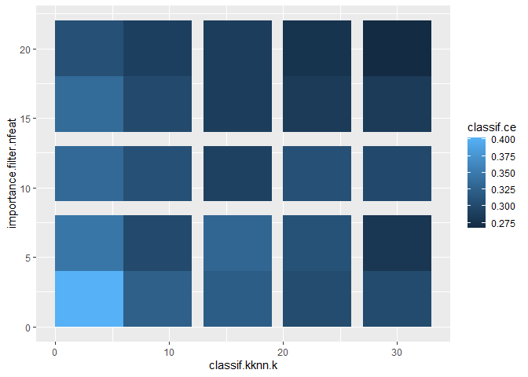

```r
library(ggplot2)
ggplot(at$archive$data, aes(x = classif.kknn.k, y = importance.filter.nfeat, fill = classif.ce)) + geom_tile()
```

## Extract the best HPs

Which of the hyperparameter combination was the best performing one?

**Hint:**

You can either inspect the plots in the previous exercise or you can have a look on the `$tuning_result` field of the trained `AutoTuner`.

### Solution:

**Click me:**

```r
at$tuning_result
```

```
##    classif.kknn.k importance.filter.nfeat learner_param_vals  x_domain classif.ce
## 1:             30                      20          <list[8]> <list[2]>  0.2669915
```

## Predict on “new” Data

The `train()` method of the `AutoTuner` automatically tunes the hyperparameters and fits a final model on the full data set using the best hyperparameters. We can see this via `at$learner$param_set()`.

Use the final model to make predictions on the following subset of the credit dataset

```r
subset = credit[5:15,]
```

**Hint:**

Use `$predict_newdata()` to predict on the new data `subset`.

### Solution:

**Click me:**

```r
at$predict_newdata(subset)
## <PredictionClassif> for 11 observations:
##     row_ids truth response
##           1   bad      bad
##           2  good     good
##           3  good     good
## ---
##           9  good     good
##          10   bad     good
##          11  good     good
```

Use `po("subsample", frac = ...)` to create a `PipeOpSample`. Concatenate it with a learner.

2. Use the following code to copy this operation 10 times and to aggregate the 10 pipelines for forming a single model.

```r
pred_set = ppl("greplicate", singlepipe, 10L)
bagging = pred_set %>>%
  po("classifavg", innum = 10)
```

3. Plot the `Graph` using `$plot()`.
4. Use `as_learner()` to transform your `Graph` into a proper `Learner`.
5. Train your stacked pipeline model using `$train()`.

### Solution:

**Click me:**

1. Create `singlepipe`

```r
singlepipe = po("subsample", frac = 0.7) %>>%
  lrn("classif.rpart")
```

2. Copy operation and create a stacked model

```r
pred_set = ppl("greplicate", singlepipe, 10L)

bagging = pred_set %>>%
  po("classifavg", innum = 10)
```

3. Plot the `Graph`

[figure not shown]

```r
bagging$plot()
```

4. Create a `GraphLearner`

```r
baglrn = as_learner(bagging)
```

5. Train the stacked model on the credit task

```r
baglrn$train(task)
```

# Summary

In this exercise sheet, we learned how to tune the whole pipeline such that preprocessing as well as model fitting can be optimized for the task at hand. We set up an `AutoTuner` object that combines the `GraphLearner` with the `Tuner` and could be used as a proper `mlr3` learner that predicts on a new dataset.

Of course, we only saw a selection of the full functionality of the `mlr3pipelines` package - if you want to learn more have a look in the mlr3book.